# Forecasting Permintaan Harian ‘Flores Fajar Blend’ - UTS Praktikum MPDW

Bryant Indervil Deadora G1401231062

```r
library(rio)
library(tidyverse)
library(ggplot2)
library(tsibble)
library(tseries)
library(MASS)
library(forecast)
library(TSA)
```

```r
dt <- import("https://raw.githubusercontent.com/bryantddr/mpdw/refs/heads/main/data_penjualan_ujian.csv")
dt <- dt %>%
  mutate(Penjualan = Penjualan + 62)
dt <- dt$Penjualan
ts.dt <- ts(dt)
ts.dt
```

```
## Time Series:
## Start = 1
## End = 500
## Frequency = 1
##   [1] 252 238 244 246 244 240 251 238 253 238 247 253 227 235 236 241 234 217
##  [19] 219 245 233 222 233 243 247 231 231 221 236 228 235 237 239 228 235 220
##  [37] 226 226 216 233 234 230 238 228 224 236 228 244 232 240 238 231 248 242
##  [55] 239 241 244 240 218 242 238 242 245 250 235 249 242 247 246 244 232 238
##  [73] 244 233 236 243 244 242 232 230 247 238 236 234 226 238 232 232 240 240
##  [91] 244 231 239 244 228 230 228 226 237 241 245 244 231 251 234 240 236 239
## [109] 241 241 240 241 237 237 229 239 238 262 233 244 234 235 247 239 247 244
## [127] 242 232 238 249 252 245 249 257 260 241 249 259 247 251 252 246 249 252
## [145] 249 260 247 246 255 241 249 238 259 249 247 241 249 243 244 257 246 238
## [163] 247 242 248 253 234 244 240 245 236 242 223 246 240 233 223 236 235 231
## [181] 231 226 232 231 228 222 237 236 227 223 236 232 236 226 229 244 239 240
```

[output cut: 17 more lines]

# Splitting Data

```r
dt.train <- dt[1:floor(0.8*length(dt))]
dt.test <- dt[(floor(0.8*length(dt))+1): length(dt)]
```

```r
ts.dt.train <- ts(dt.train)
ts.dt.test <- ts(dt.test)
```

# Ekplorasi Data

## Plot Time Series

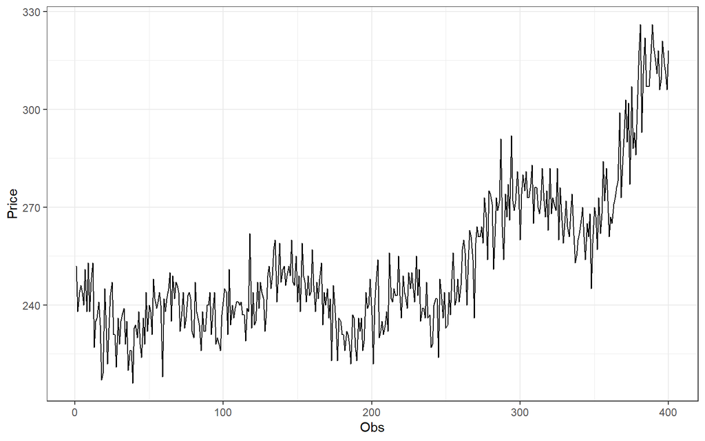

```r
plot_dt <- ts.dt.train |> as_tsibble() |>
  ggplot(aes(x = index, y = value)) + geom_line() + theme_bw() +
  xlab("Obs") + ylab("Price")
plot_dt
```

```r
mean(ts.dt.train)
```

```
## [1] 252.465
```

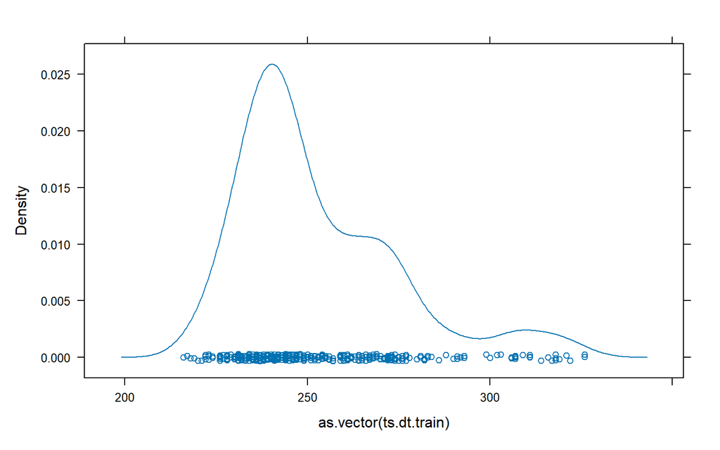

```r
lattice::densityplot(as.vector(ts.dt.train))
```

Berdasarkan plot, terlihat data tidak stasioner dalam rataan, ditandai data tidak menyebar di sekitar nilai tengahnya, cenderung adanya tren. Namun, cenderung stasioner dalam ragam, ditandai dengan lebar fluktuasi yang mirip.

## Plot ACF

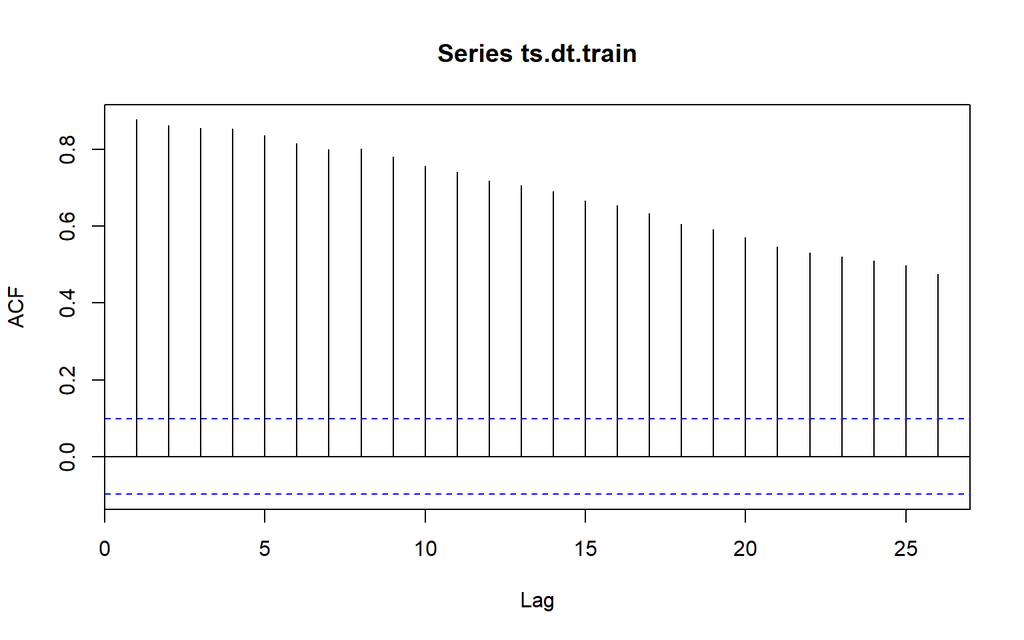

```r
acf(ts.dt.train)
```

Berdasarkan plot ACF, terlihat plot tails off slowly. Hal ini mengindikasikan terdapat tidak stationer dalam rataan. Hal ini sesuai dengan ekplorasi time series plot.

## Uji ADF

```r
adf.test(ts.dt.train)
```

```
##
##  Augmented Dickey-Fuller Test
##
## data:  ts.dt.train
## Dickey-Fuller = -1.0344, Lag order = 7, p-value = 0.9325
## alternative hypothesis: stationary
```

$H_0$ : Data tidak stasioner dalam rataan $H_1$ : Data stasioner dalam rataan

Berdasarkan hasil uji ADF, *p-value* = 0.9325 > 0.05 = $\alpha$, maka tak tolak $H_0$. Data tidak stasioner dalam rataan. Hal ini sesuai dengan *time series* dan ACF plot.

Dalam data penjualan, hal ini hampir pasti terjadi. Oleh karena itu, akan dilakukan pengananan lebih lanjut.

## Uji Box-Cox

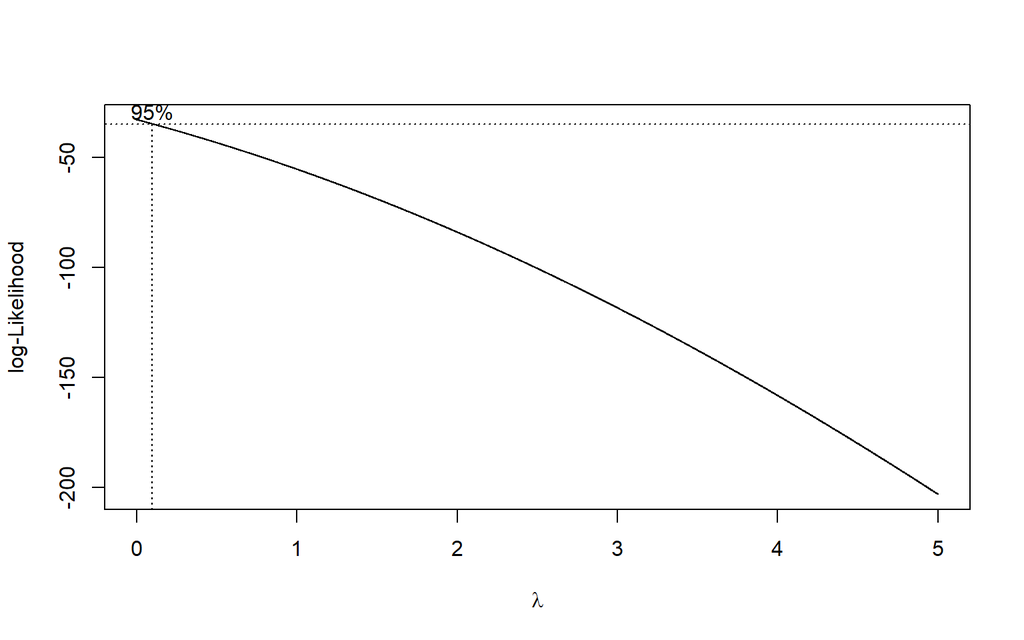

```r
index <- seq(1:length(ts.dt.train))

# Uji Box-Cox
bc <- boxcox(
  ts.dt.train  ~ index,
  lambda = seq(0, 5, by = 0.001)
)
```

```r
lambda <- bc$x[which.max(bc$y)]
lambda
```

```
## [1] 0
```

```r
# Selang kepercayaan 95% untuk lambda
ci_lambda <- bc$x[bc$y > max(bc$y) - 0.5 * qchisq(0.95, 1)]

# Batas bawah dan batas atas
ci_lower <- min(ci_lambda)
ci_upper <- max(ci_lambda)

c(Batas_Bawah = ci_lower, Batas_Atas = ci_upper)
```

```
## Batas_Bawah  Batas_Atas
##       0.000       0.097
```

Hasil uji Box-Cox menunjukkan bahwa nilai $\lambda$ optimum adalah 0 dengan interval kepercayaan 95% (0,0.097). Selang tidak mengandung $\lambda$ = 1, maka data tidak stasioner dalam ragam. Perlu penanganan lebih lanjut dengan melakukan transformasi Box-Cox

# Penanganan Ketidakstasioneran Data

## Differencing

```r
ts.dt.train_diff1 <- diff(ts.dt.train, differences = 1)
```

## Plot Time Series

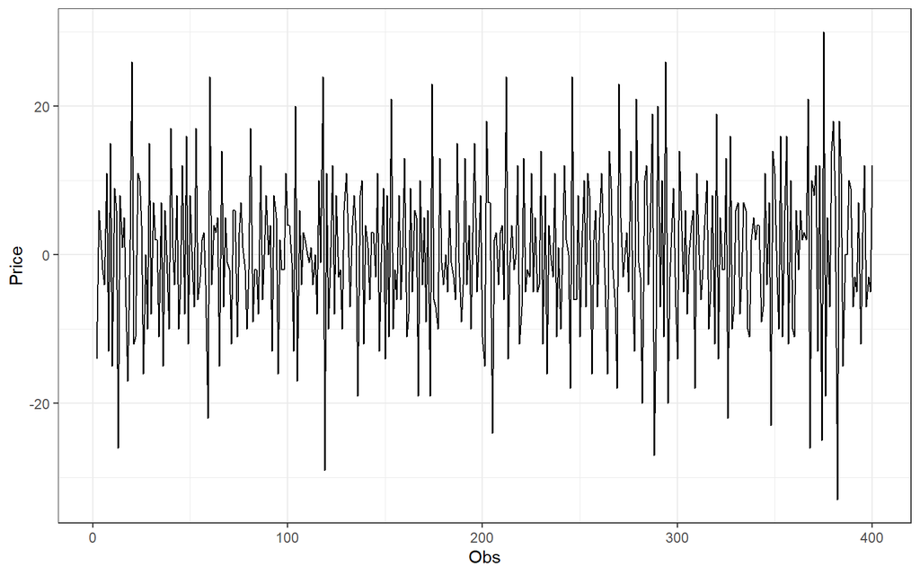

```r
plot_dt.train_diff1 <- ts.dt.train_diff1 |> as_tsibble() |>
  ggplot(aes(x = index, y = value)) + geom_line() + theme_bw() +
  xlab("Obs") + ylab("Price")
plot_dt.train_diff1
```

Berdasarkan plot, data terlihat menyebar pada rataan yang berarti stasioner pada rataan. Namun, sekilas terlihat belum stasioner pada ragam.

## Plot ACF

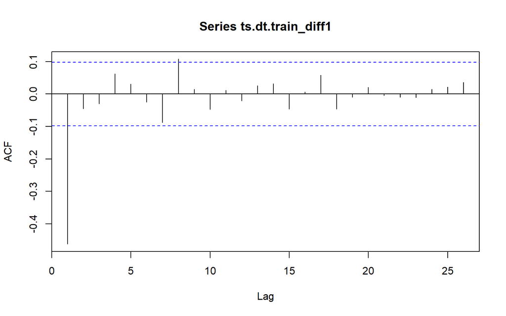

```r
acf(ts.dt.train_diff1)
```

Berdasarkan Plot ACF, terlihat sudah stasioner dalam rataan, ditandai dengan plot ACF cuts off pada lag 1. Hasil ini sama dengan time series plot.

## Uji ADF

```r
adf.test(ts.dt.train_diff1)
```

```
##
##  Augmented Dickey-Fuller Test
##
## data:  ts.dt.train_diff1
## Dickey-Fuller = -10.583, Lag order = 7, p-value = 0.01
## alternative hypothesis: stationary
```

$H_0$ : Data tidak stasioner dalam rataan $H_1$ : Data stasioner dalam rataan

## Uji Box-Cox

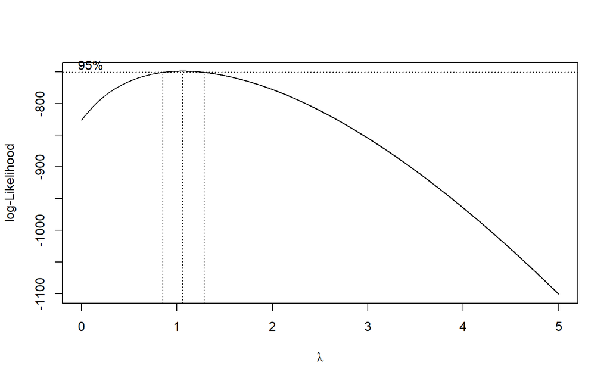

```r
index <- seq(1:(length(ts.dt.train)-1))

# Uji Box-Cox
bc <- boxcox(
  ts.dt.train_diff1 - min(ts.dt.train_diff1) + 1  ~ index,
  lambda = seq(0, 5, by = 0.001)
)
```

```r
# Selang kepercayaan 95% untuk lambda
ci_lambda <- bc$x[bc$y > max(bc$y) - 0.5 * qchisq(0.95, 1)]

# Batas bawah dan batas atas
ci_lower <- min(ci_lambda)
ci_upper <- max(ci_lambda)

c(Batas_Bawah = ci_lower, Batas_Atas = ci_upper)
```

```
## Batas_Bawah  Batas_Atas
##       0.852       1.285
```

Berdasarkan Uji Box-Cox, interval kepercayaan 95% $\lambda$ sebesar (0.852,1.285). Dalam selang ini terdapat nilai $\lambda$ = 1, maka data sudah stasioner dalam ragam. Tanpa melakukan transformasi Box-Cox, data sudah stasioner dalam ragam. Oleh karena itu, tidak perlu dilakukan transformasi.

# Identifikasi Model

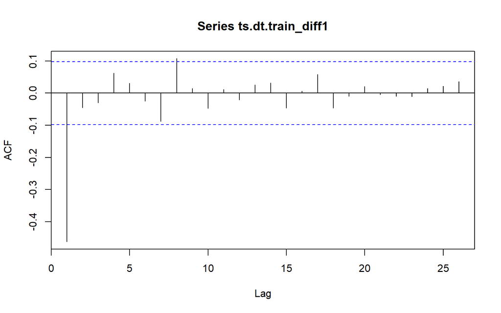

```r
acf(ts.dt.train_diff1)
```

Berdasarkan Plot ACF, terlihat plot ACF cuts off pada lag 1, jika asumsi plot PACF tails off model yang baik digunakan adalah MA(1)

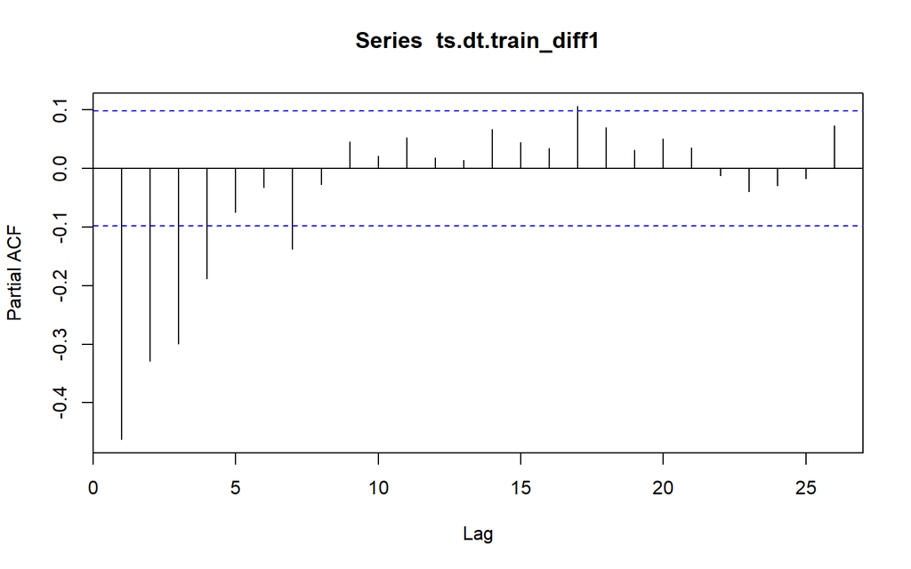

```r
pacf(ts.dt.train_diff1)
```

Berdasarkan plot PACF, terlihat plot PACF tails off. Hal ini meyakinkan bahwa model yang akan digunakan adalah MA(1)

```r
eacf(ts.dt.train_diff1)
```

```
## AR/MA
##   0 1 2 3 4 5 6 7 8 9 10 11 12 13
## 0 x o o o o o o x o o o  o  o  o
## 1 x x o o o o o o o o o  o  o  o
## 2 x x x o o o o o o o o  o  o  o
## 3 x x x x o o o o o o o  o  o  o
## 4 x o o x x o o o o o o  o  o  o
## 5 x o x x x x o o o o o  o  o  o
## 6 x x x x x x x o o o o  o  o  o
## 7 x x o x o x x o o o o  o  o  o
```

Berdasarkan plot EACF, segitiga bawah teratas adalah model ARMA(0,1) atau sama saja dengan MA(1)

# Pemodelan

Berdasarkan ACF, PACF, EACF plot, model yang akan digunakan adalah model MA(1)

```r
model1.da=Arima(ts.dt.train_diff1, order=c(0,0,1))
summary(model1.da)
```

```
## Series: ts.dt.train_diff1
## ARIMA(0,0,1) with non-zero mean
##
## Coefficients:
##           ma1    mean
##       -0.7541  0.1740
## s.e.   0.0270  0.1026
##
## sigma^2 = 68.78:  log likelihood = -1409.63
## AIC=2825.27   AICc=2825.33   BIC=2837.24
##
## Training set error measures:
##                       ME     RMSE      MAE MPE MAPE      MASE        ACF1
## Training set -0.03040027 8.272406 6.524455 NaN  Inf 0.4579776 -0.03134008
```

```r
lmtest::coeftest(model1.da)
```

```
##
## z test of coefficients:
##
##            Estimate Std. Error  z value Pr(>|z|)
## ma1       -0.754118   0.027045 -27.8839   <2e-16 ***
## intercept  0.173994   0.102626   1.6954     0.09 .
## ---
## Signif. codes:  0 '***' 0.001 '**' 0.01 '*' 0.05 '.' 0.1 ' ' 1
```

Berdasarkan hasil z test, didapatkan *p-value* = $2 \times 10^{-16}$ < 0.05 = $\alpha$, maka tolak $H_0$.

Koefisien ma1 signifikan

# Analisis Sisaan

## Ekplorasi Sisaan

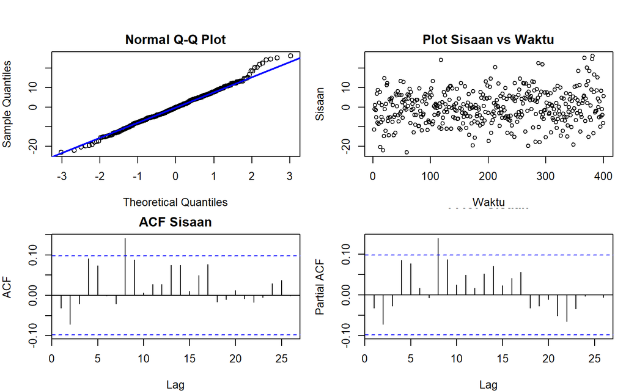

```r
sisaan.da <- model1.da$residuals

par(mfrow = c(2,2),
    mar = c(4,4,2,1),
    oma = c(0,0,2,0))

# Q-Q Plot
qqnorm(sisaan.da, main = "Normal Q-Q Plot")
qqline(sisaan.da, col = "blue", lwd = 2)

# Plot Sisaan vs Waktu
plot(sisaan.da, type = "p",
     main = "Plot Sisaan vs Waktu",
     xlab = "Waktu", ylab = "Sisaan")

# ACF
acf(sisaan.da, main = "ACF Sisaan")

# PACF
pacf(sisaan.da, main = "PACF Sisaan")
```

Berdasarkan plot kuantil-kuantil normal, secara eksploratif terlihat bahwa sisaan menyebar normal karena titik-titik cenderung menyebar pada garis. Selain itu, lebar pita sebaran sisaan tampak seragam, yang mengindikasikan ragam homogen. Sementara itu, plot ACF dan PACF sisaan dari model MA(1) menunjukkan adanya spike signifikan pada lag ke 8, secara visual sisaan dapat terindikasi tidak saling bebas. Kondisi ini akan diuji lebih lanjut dengan uji formal.

## Uji Formal

```r
shapiro.test(sisaan.da)
```

```
##
##  Shapiro-Wilk normality test
##
## data:  sisaan.da
## W = 0.99447, p-value = 0.1602
```

$H_0$: Sisaan menyebar normal $H_1$: Sisaan tidak menyebar normal

```r
Box.test(sisaan.da, type = "Ljung")
```

```
##
##  Box-Ljung test
##
## data:  sisaan.da
## X-squared = 0.39485, df = 1, p-value = 0.5298
```

$H_0$: Sisaan saling bebas $H_1$: Sisaan tidak saling bebas

Berdasarkan uji Ljung-Box tersebut, didapat p-value sebesar 0.5298 > 0.05 = $\alpha$ sehingga gagal tolak $H_0$ dan menandakan bahwa sisaan saling bebas. Hal ini berbeda dengan eksplorasi.

```r
Box.test((sisaan.da)^2, type = "Ljung")
```

```
##
##  Box-Ljung test
##
## data:  (sisaan.da)^2
## X-squared = 1.6802, df = 1, p-value = 0.1949
```

$H_0$: Ragam sisaan homogen $H_1$: Ragam sisaan tidak homogen

Berdasarkan uji Ljung-Box terhadap sisaan kuadrat tersebut, didapat p-value sebesar 0.1949 > 0.05 = $\alpha$ sehingga gagal tolak $H_0$ dan menandakan bahwa ragam sisaan homogen.

```r
t.test(sisaan.da, mu = 0, conf.level = 0.95)
```

```
##
##  One Sample t-test
##
## data:  sisaan.da
## t = -0.073315, df = 398, p-value = 0.9416
## alternative hypothesis: true mean is not equal to 0
## 95 percent confidence interval:
##  -0.8455889  0.7847884
## sample estimates:
##   mean of x
## -0.03040027
```

$H_0$: Nilai tengah sisaan sama dengan 0 $H_1$: Nilai tengah sisaan tidak sama dengan 0

Berdasarkan uji-t, didapat p-value sebesar 0.9416 > 0.05 = $\alpha$sehingga gagal tolak $H_0$ dan menandakan bahwa nilai tengah sisaan sama dengan nol.

# Akurasi Model

Akurasi dilakukan dengan forecast data test dan dibandingkan dengan data test. Metriks yang digunakan adalah *Mean Absolute Percentage Error* (MAPE)

```r
ramalan.da <- forecast(model1.da, h = length(ts.dt.test))
```

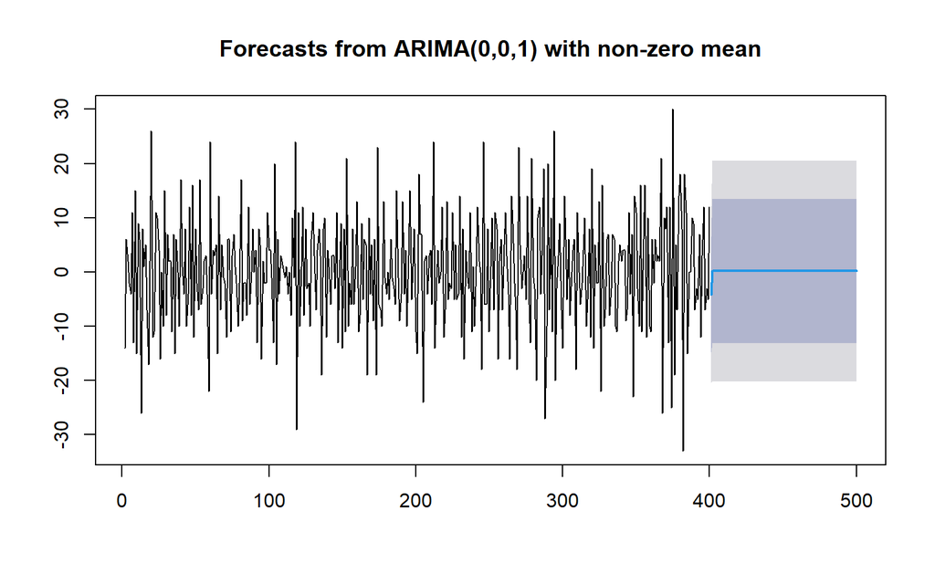

```r
dt.ramalan.da <- ramalan.da$mean
plot(ramalan.da)
```

```r
pt_akhir_train <- tail(ts.dt.test, 1)

forecast <- diffinv(dt.ramalan.da, differences = 1, xi = pt_akhir_train)
hasil <- forecast[-1]
hasil <- forecast[1:length(ts.dt.test)]

# Bandingkan aktual vs forecast
perbandingan.da <- cbind(
  Aktual   = ts.dt.test,
  Forecast = hasil
)

print(head(perbandingan.da, 10))
```

```
## Time Series:
## Start = 1
## End = 10
## Frequency = 1
##    Aktual Forecast
##  1    321 368.0000
##  2    299 363.8537
##  3    307 364.0277
##  4    306 364.2017
##  5    301 364.3757
##  6    298 364.5497
##  7    308 364.7237
##  8    315 364.8977
##  9    324 365.0717
## 10    291 365.2457
```

```r
akurasi_test <- accuracy(hasil, ts.dt.test)
akurasi_test
```

```
##                 ME     RMSE      MAE       MPE     MAPE      ACF1 Theil's U
## Test set -26.82561 33.19897 27.78584 -8.190595 8.437878 0.6394864  2.153045
```

Didapatkan hasil MAPE sebesar 8.43%, akurasi yang didapatkan cukup moderat dan bisa digunakan untuk forecast 30 hari ke depan.

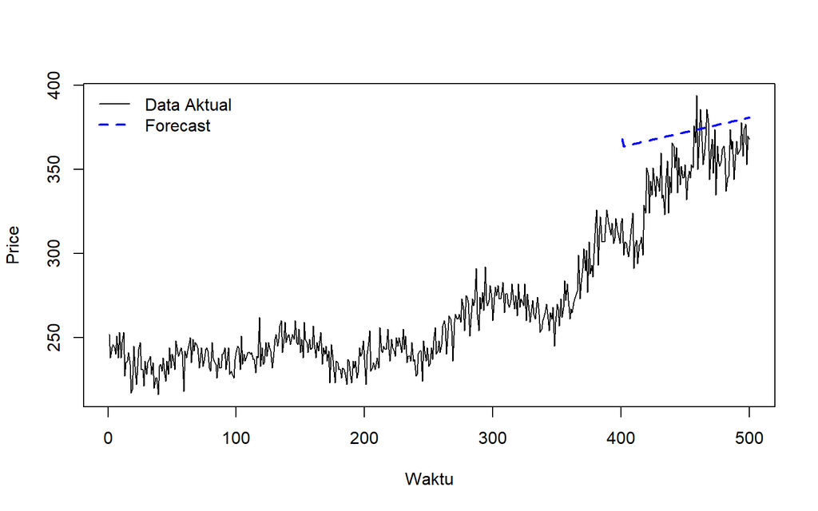

```r
ts.plot(ts.dt, col = "black", lty = 1,
        xlab = "Waktu", ylab = "Price")

# Garis forecast
lines((length(ts.dt.train)+1):length(ts.dt), hasil, col = "blue", lty = 2, lwd = 2)
legend("topleft",
       legend = c("Data Aktual", "Forecast"),
       col = c("black", "blue"),
       lty = c(1,2,3), lwd = c(1,2,1), bty = "n")
```

# Forecast

```r
ramalan.da2 <- forecast(model1.da, h = (length(ts.dt.test) + 30))
```

```r
ramalan.da2
```

```
##     Point Forecast     Lo 80     Hi 80     Lo 95    Hi 95
## 401     -4.1462886 -14.77447  6.481896 -20.40069 12.10812
## 402      0.1739937 -13.13754 13.485531 -20.18425 20.53223
## 403      0.1739937 -13.13754 13.485531 -20.18425 20.53223
## 404      0.1739937 -13.13754 13.485531 -20.18425 20.53223
## 405      0.1739937 -13.13754 13.485531 -20.18425 20.53223
## 406      0.1739937 -13.13754 13.485531 -20.18425 20.53223
## 407      0.1739937 -13.13754 13.485531 -20.18425 20.53223
## 408      0.1739937 -13.13754 13.485531 -20.18425 20.53223
## 409      0.1739937 -13.13754 13.485531 -20.18425 20.53223
## 410      0.1739937 -13.13754 13.485531 -20.18425 20.53223
## 411      0.1739937 -13.13754 13.485531 -20.18425 20.53223
## 412      0.1739937 -13.13754 13.485531 -20.18425 20.53223
## 413      0.1739937 -13.13754 13.485531 -20.18425 20.53223
## 414      0.1739937 -13.13754 13.485531 -20.18425 20.53223
```

[output cut: 116 more lines]

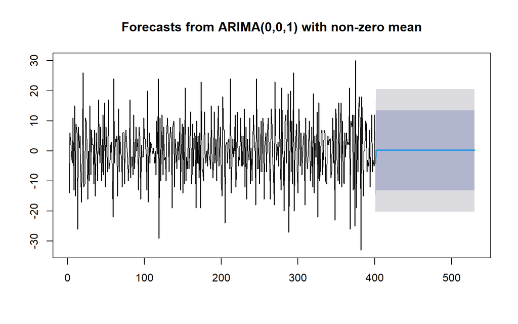

```r
dt.ramalan.da2 <- ramalan.da2$mean
plot(ramalan.da2)
```

```r
pt_akhir <- tail(ts.dt.test+30, 1)

forecast <- diffinv(dt.ramalan.da2, differences = 1, xi = pt_akhir_train)
hasil2 <- forecast[-1]
hasil2 <- forecast[1:(length(ts.dt.test)+30)]
```

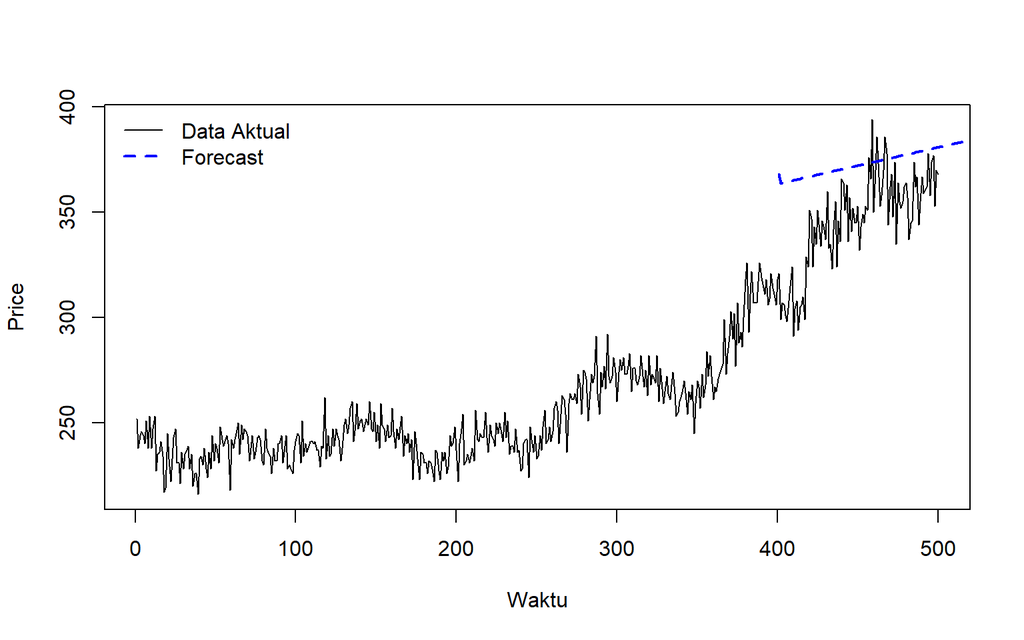

```r
ts.plot(ts.dt, col = "black", lty = 1,
        xlab = "Waktu", ylab = "Price")

# Garis forecast
lines((length(ts.dt.train)+1):(length(ts.dt)+30), hasil2, col = "blue", lty = 2, lwd = 2)
legend("topleft",
       legend = c("Data Aktual", "Forecast"),
       col = c("black", "blue"),
       lty = c(1,2,3), lwd = c(1,2,1), bty = "n")
```

```r
hasil2[101:130]
```

```
##  [1] 381.0791 381.2531 381.4271 381.6011 381.7751 381.9491 382.1231 382.2970
##  [9] 382.4710 382.6450 382.8190 382.9930 383.1670 383.3410 383.5150 383.6890
## [17] 383.8630 384.0370 384.2110 384.3850 384.5590 384.7330 384.9070 385.0809
## [25] 385.2549 385.4289 385.6029 385.7769 385.9509 386.1249
```

Berikut hasil forecasting selama 30 hari ke depan.

# Kesimpulan dan Rekomendasi

> Berdasarkan hasil forecasting terlihat akan ada tren naik permintaan ‘Flores Fajar Blend’ pada 30 hari ke depan. Rekomendasi yang dapat disampaikan adalah meningkatkan produksi pada ‘Flores Fajar Blend’ setiap harinya secara perlahan dengan kenaikan produksi sekitar 0.2kg per hari.